# salpa: Satellite Lidar Point Alignment

## Overview

`salpa` (Satellite Lidar Point Alignment) is an R package for improving the spatial accuracy of satellite lidar data through positional correction. It addresses the issue of horizontal positional errors in satellite lidar measurements by aligning them with high-resolution reference elevation models.

The package implements various optimization algorithms and comparison metrics to find the optimal horizontal adjustment for lidar footprints. This vignette demonstrates the package’s capabilities and compares the performance of different optimization methods.

## Installation

You can install the development version of the package from GitHub:

```r
# install.packages("remotes")
remotes::install_github("naru-T/salpa")
```

## Required Packages

```r
library(salpa)
library(sf)
library(terra)
library(exactextractr)
library(raster)
```

```r
library(ggplot2)
library(dplyr)
```

## Data Preparation

Let’s load the sample GEDI L2A data included with the package:

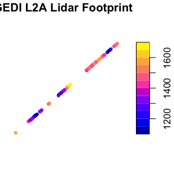

```r
# Load GEDI L2A sample data
gpkg_path <- system.file("extdata", "gedi_l2a_shot_sample.gpkg", package = "salpa")
lidar_footprints <- st_read(gpkg_path, quiet = TRUE)

lidar_footprints <- lidar_footprints %>% mutate(gedi_dem = as.numeric(elev_lowestmode) - as.numeric(geoid))
# Look at the data
#head(lidar_footprints)
plot(lidar_footprints["gedi_dem"], pch = 20, main = "GEDI L2A Lidar Footprints")
```

## Reference DEM Preparation

To perform positional adjustment, we need a reference Digital Elevation Model (DEM). For this example, we’ll use the `elevatr` package to obtain a DEM for our area of interest:

```r
# Define area of interest
bbox_4326 <- st_bbox(c(xmin = 139.40119, ymin = 36.86163,
                      xmax = 139.52543, ymax = 36.94841),
                    crs = 4326)
bbox_sf <- st_as_sf(st_as_sfc(bbox_4326))


# Get reference DEM
dem <- elevatr::get_elev_raster(bbox_sf, z = 12, clip = "bbox")
```

```
#> Mosaicing & Projecting
#> Clipping DEM to bbox
#> Note: Elevation units are in meters.
```

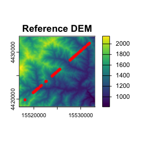

```r
dem_3857 <- raster::projectRaster(dem, crs = 3857)
dem_rast <- terra::rast(dem_3857)

# Transform lidar footprints to Web Mercator
lidar_footprints_3857 <- st_transform(lidar_footprints, 3857)

# Plot DEM
plot(dem_rast, main = "Reference DEM")
plot(st_geometry(lidar_footprints_3857), add = TRUE, pch = 20, col = "red")
```

## Positional Adjustment

Now let’s apply positional adjustment using different optimization methods to see which one works best for our data.

### Using Genetic Algorithm (GA)

The Genetic Algorithm mimics natural selection processes and is good for complex search spaces.

```r
# Apply positional correction using GA
ga_result <- positional_correction(
  lidar_footprints = lidar_footprints_3857,
  input_rast = dem_rast,
  minimizing_method = "euclidean",
  target_variable = "mean",
  lidar_value = "gedi_dem",
  buf = 12.5,
  lower_bounds = c(-1000, -1000),
  upper_bounds = c(1000, 1000),
  crs_code = 3857,
  optimization_method = "ga",
  max_iter = 200,
  pop_size = 20
)
```

```
#> GA bounds: -1000 -1000 to 1000 1000
#> GA pop_size: 20 max_iter: 200 parallel: FALSE
#> [GA fitness eval #1] x=(0,0) -> obj_value = 40.58204
#> [GA fitness eval #101] x=(211.1473,119.827) -> obj_value = 26.20858
#> [GA fitness eval #201] x=(124.8713,107.1701) -> obj_value = 13.97083
#> [GA fitness eval #301] x=(23.27766,104.4675) -> obj_value = 23.48803
#> [GA fitness eval #401] x=(100.3342,97.79608) -> obj_value = 12.69573
#> [GA fitness eval #501] x=(100.8366,98.44275) -> obj_value = 12.68894
#> [GA fitness eval #601] x=(100.8065,98.27355) -> obj_value = 12.68888
#> [GA fitness eval #701] x=(100.8061,98.27356) -> obj_value = 12.68888
```

```r
# Print optimization result
print(ga_result$optim_result)
```

```
#>     best_x   best_y best_value
#> 1 100.8061 98.27356   12.68887
```

### Using Particle Swarm Optimization (PSO)

PSO is inspired by the social behavior of bird flocking and is effective for continuous optimization problems.

```r
# Apply positional correction using PSO
pso_result <- positional_correction(
  lidar_footprints = lidar_footprints_3857,
  input_rast = dem_rast,
  minimizing_method = "euclidean",
  target_variable = "mean",
  lidar_value = "gedi_dem",
  buf = 12.5,
  lower_bounds = c(-1000, -1000),
  upper_bounds = c(1000, 1000),
  crs_code = 3857,
  optimization_method = "pso",
  max_iter = 200,
  pop_size = 20,
  pso_params = list(
    trace = TRUE,     # Whether to print progress
    abstol = 1e-4,     # Absolute tolerance
    reltol = 1e-4,     # Relative tolerance
    REPORT = 10         # Report every 5 iterations
  )
)
```

```
#> PSO Iteration 1: Best fitness = 15.63515320
#> PSO Iteration 20: Best fitness = 12.69023171
#> PSO Iteration 40: Best fitness = 12.68897160
#> PSO Iteration 60: Best fitness = 12.68886740
#> PSO early stopping at iteration 77
```

```r
# Print optimization result
print(pso_result$optim_result)
```

```
#>     best_x   best_y best_value
#> 1 100.8165 98.31844   12.68886
```

### Using Whale Optimization Algorithm (WOA)

WOA is inspired by the bubble-net hunting strategy of humpback whales and excels at balancing exploration and exploitation.

```r
# Apply positional correction using WOA
woa_result <-  positional_correction(
    lidar_footprints = lidar_footprints_3857,
    input_rast = dem_rast,
    minimizing_method = "euclidean",
    target_variable = "mean",
    lidar_value = "gedi_dem",
    buf = 12.5,
    lower_bounds = c(-1000, -1000),
    upper_bounds = c(1000, 1000),
    crs_code = 3857,
    optimization_method = "woa",   # Whale Optimization Algorithm
    max_iter = 200,
    pop_size = 20,
    woa_params = list(
      verbose = TRUE,   # Whether to print progress
      batch_size = 10    # Process all positions in one batch
    )
  )
```

```
#> WOA Iteration 1: Best fitness = 16.04127433
#> WOA Iteration 20: Best fitness = 12.69044139
#> WOA Iteration 40: Best fitness = 12.68994385
#> WOA Iteration 60: Best fitness = 12.68994385
#> WOA early stopping at iteration 74
```

```r
# Print optimization result if available
print(woa_result$optim_result)
```

```
#>     best_x   best_y best_value
#> 1 100.5546 97.14167   12.68994
```

### Using L-BFGS-B Algorithm

L-BFGS-B is a quasi-Newton method that approximates the Broyden–Fletcher–Goldfarb–Shanno algorithm using a limited amount of memory. It’s particularly efficient for well-behaved functions.

```r
# Apply positional correction using L-BFGS-B with error handling
lbfgsb_result <-  positional_correction(
    lidar_footprints = lidar_footprints_3857,
    input_rast = dem_rast,
    minimizing_method = "euclidean",
    target_variable = "mean",
    lidar_value = "gedi_dem",
    buf = 12.5,
    lower_bounds = c(-1000, -1000),
    upper_bounds = c(1000, 1000),
    crs_code = 3857,
    optimization_method = "lbfgsb",  # L-BFGS-B
    max_iter = 200,
    lbfgsb_params = list(
      factr = 1e7,        # Control precision
      pgtol = 1e-5,       # Gradient tolerance
      trace = 0           # No tracing
    )
  )

# Print optimization result if available
print(lbfgsb_result$optim_result)
```

```
#>     best_x   best_y best_value
#> 1 105.8771 97.58413   12.81527
```

### Comparing X/Y Adjustments

Let’s visualize and compare the positional adjustments made by all four optimization methods:

```r
# Function to safely get values from optimization results
posit_result_get <- function(result, default = 0) {
  if (!is.null(result) && !is.null(result$optim_result)) {
    return(result$optim_result)
  } else {
    # Return default values if result is NULL
    warning("Optimization result was NULL, using default values instead")
    return(list(best_x = default, best_y = default, best_value = NA))
  }
}

# Create a data frame of adjustment values
adjustments <- data.frame(
  Method = c("GA", "PSO", "WOA", "L-BFGS-B"),
  X_Adjustment = c(
    posit_result_get(ga_result)$best_x,
    posit_result_get(pso_result)$best_x,
    posit_result_get(woa_result)$best_x,
    posit_result_get(lbfgsb_result)$best_x
  ),
  Y_Adjustment = c(
    posit_result_get(ga_result)$best_y,
    posit_result_get(pso_result)$best_y,
    posit_result_get(woa_result)$best_y,
    posit_result_get(lbfgsb_result)$best_y
  ),
  Fitness_Value = c(
    posit_result_get(ga_result)$best_value,
    posit_result_get(pso_result)$best_value,
    posit_result_get(woa_result)$best_value,
    posit_result_get(lbfgsb_result)$best_value
  )
)

# Print the adjustment values
print(adjustments)
```

```
#>     Method X_Adjustment Y_Adjustment Fitness_Value
#> 1       GA     100.8061     98.27356      12.68887
#> 2      PSO     100.8165     98.31844      12.68886
#> 3      WOA     100.5546     97.14167      12.68994
#> 4 L-BFGS-B     105.8771     97.58413      12.81527
```

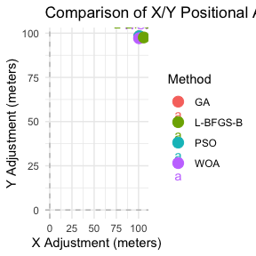

```r
# Plot X and Y adjustments
ggplot(adjustments, aes(x = X_Adjustment, y = Y_Adjustment, color = Method)) +
  geom_point(size = 4) +
  geom_text(aes(label = Method), vjust = -1) +
  geom_hline(yintercept = 0, linetype = "dashed", color = "gray") +
  geom_vline(xintercept = 0, linetype = "dashed", color = "gray") +
  theme_minimal() +
  labs(title = "Comparison of X/Y Positional Adjustments",
       x = "X Adjustment (meters)",
       y = "Y Adjustment (meters)")
```

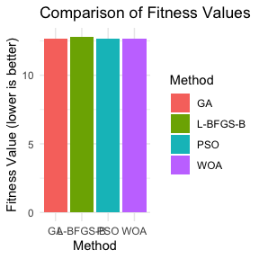

```r
# Plot fitness values (excluding NA values)
adjustments_filtered <- adjustments[!is.na(adjustments$Fitness_Value),]
if(nrow(adjustments_filtered) > 0) {
  ggplot(adjustments_filtered, aes(x = Method, y = Fitness_Value, fill = Method)) +
    geom_bar(stat = "identity") +
    theme_minimal() +
    labs(title = "Comparison of Fitness Values",
         y = "Fitness Value (lower is better)",
         x = "Method")
} else {
  cat("No valid fitness values to plot")
}
```

## Evaluation of DEM Differences

Let’s compare the original and corrected lidar values with the reference DEM for all methods:

```r
# Create buffered footprints for extraction
buffered_original <- st_buffer(lidar_footprints_3857, 12.5)

# Use safe buffering function to handle possible NULL results
make_buffer <- function(result, crs_code = 3857, buffer_size = 12.5) {
  if (!is.null(result)) {
    best_x <- result$optim_result$best_x
    best_y <- result$optim_result$best_y
    adjusted_footprints <- position_adjustment(lidar_footprints_3857, best_x, best_y, crs_code)
    return(st_buffer(adjusted_footprints, buffer_size))
  } else {
    # Return the original footprints if result is NULL
    warning("Optimization result was NULL, using original footprints instead")
    return(buffered_original)
  }
}

# Safely create buffered footprints
buffered_ga <- make_buffer(ga_result)
buffered_pso <- make_buffer(pso_result)
buffered_woa <- make_buffer(woa_result)
buffered_lbfgsb <- make_buffer(lbfgsb_result)

# Extract values from each buffered dataset
original_extracted <- exact_extract(dem_rast, buffered_original, "mean", progress = FALSE)
ga_extracted <- exact_extract(dem_rast, buffered_ga, "mean", progress = FALSE)
pso_extracted <- exact_extract(dem_rast, buffered_pso, "mean", progress = FALSE)
woa_extracted <- exact_extract(dem_rast, buffered_woa, "mean", progress = FALSE)
lbfgsb_extracted <- exact_extract(dem_rast, buffered_lbfgsb, "mean", progress = FALSE)

# Get lidar values
lidar_values <- as.numeric(lidar_footprints_3857$gedi_dem)

# Print summary stats for each dataset
cat("Original values summary:\n")
```

```
#> Original values summary:
```

```r
print(summary(original_extracted))
```

```
#>    Min. 1st Qu.  Median    Mean 3rd Qu.    Max.
#>    1111    1326    1451    1420    1516    1687
```

```r
cat("\nGA corrected values summary:\n")
```

```
#>
#> GA corrected values summary:
```

```r
print(summary(ga_extracted))
```

```
#>    Min. 1st Qu.  Median    Mean 3rd Qu.    Max.
#>    1110    1320    1444    1421    1525    1692
```

```r
cat("\nPSO corrected values summary:\n")
```

```
#>
#> PSO corrected values summary:
```

```r
print(summary(pso_extracted))
```

```
#>    Min. 1st Qu.  Median    Mean 3rd Qu.    Max.
#>    1110    1320    1444    1421    1525    1692
```

```r
cat("\nWOA corrected values summary:\n")
```

```
#>
#> WOA corrected values summary:
```

```r
print(summary(woa_extracted))
```

```
#>    Min. 1st Qu.  Median    Mean 3rd Qu.    Max.
#>    1110    1321    1444    1421    1525    1692
```

```r
cat("\nL-BFGS-B corrected values summary:\n")
```

```
#>
#> L-BFGS-B corrected values summary:
```

```r
print(summary(lbfgsb_extracted))
```

```
#>    Min. 1st Qu.  Median    Mean 3rd Qu.    Max.
#>    1109    1321    1443    1421    1523    1692
```

```r
cat("\nLidar values summary:\n")
```

```
#>
#> Lidar values summary:
```

```r
print(summary(lidar_values))
```

```
#>    Min. 1st Qu.  Median    Mean 3rd Qu.    Max.
#>    1110    1316    1445    1414    1516    1689
```

### Mean Absolute Error (MAE) Analysis

Let’s calculate and compare the Mean Absolute Error (MAE) for all methods:

```r
# Create a safe function to calculate MAE
calc_mae <- function(lidar_values, extracted_values, method_name) {
  if (length(extracted_values) == 0 || all(is.na(extracted_values))) {
    warning("No valid values for method: ", method_name)
    return(NA)
  }

  # Ensure both vectors are the same length
  min_length <- min(length(lidar_values), length(extracted_values))

  if (min_length == 0) {
    warning("Zero-length vectors for method: ", method_name)
    return(NA)
  }

  # Calculate MAE with proper handling of NA values
  mae <- mean(abs(lidar_values[1:min_length] - extracted_values[1:min_length]), na.rm = TRUE)

  if (is.nan(mae) || is.na(mae)) {
    warning("MAE calculation resulted in NaN for method: ", method_name)
    return(NA)
  }

  return(mae)
}

# Calculate MAE for each method
original_mae <- calc_mae(lidar_values, original_extracted, "Original")
ga_mae <- calc_mae(lidar_values, ga_extracted, "GA")
pso_mae <- calc_mae(lidar_values, pso_extracted, "PSO")
woa_mae <- calc_mae(lidar_values, woa_extracted, "WOA")
lbfgsb_mae <- calc_mae(lidar_values, lbfgsb_extracted, "L-BFGS-B")


# Create a data frame for plotting
mae_df <- data.frame(
  Method = c("Original", "GA", "PSO", "WOA", "L-BFGS-B"),
  MAE = c(original_mae, ga_mae, pso_mae, woa_mae, lbfgsb_mae)
)

# Print MAE values
print(mae_df)
```

```
#>     Method      MAE
#> 1 Original 40.58204
#> 2       GA 12.68887
#> 3      PSO 12.68886
#> 4      WOA 12.68994
#> 5 L-BFGS-B 12.81527
```

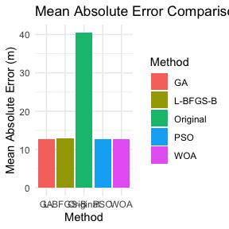

```r
# Filter out NA values for plotting
mae_df_filtered <- mae_df[!is.na(mae_df$MAE),]

# Plot MAE comparison if there are valid values
if (nrow(mae_df_filtered) > 0) {
  ggplot(mae_df_filtered, aes(x = Method, y = MAE, fill = Method)) +
    geom_bar(stat = "identity") +
    theme_minimal() +
    labs(title = "Mean Absolute Error Comparison",
         y = "Mean Absolute Error (m)",
         x = "Method")
} else {
  cat("No valid MAE values to plot")
}
```

### Execution Time Comparison

Let’s compare the computational efficiency of each optimization method:

```r
# Function to run optimization method with timing
time_optimization <- function(method, params) {
  start_time <- Sys.time()

  result <- tryCatch({
    # Create a new list with the optimization_method parameter
    all_params <- params
    all_params$optimization_method <- method

    # Call the function with do.call to properly pass all parameters
    do.call(positional_correction, all_params)
  }, error = function(e) {
    warning(paste(method, "optimization failed:", conditionMessage(e)))
    return(NULL)
  })

  end_time <- Sys.time()
  execution_time <- as.numeric(difftime(end_time, start_time, units = "secs"))

  return(list(
    result = result,
    time = execution_time
  ))
}

# Common parameters for all methods
common_params <- list(
  lidar_footprints = lidar_footprints_3857,
  input_rast = dem_rast,
  minimizing_method = "euclidean",
  target_variable = "mean",
  lidar_value = "gedi_dem",
  buf = 12.5,
  lower_bounds = c(-1000, -1000),
  upper_bounds = c(1000, 1000),
  crs_code = 3857,
  max_iter = 100,
  pop_size = 20
)

# Time each method
cat("Running timing tests (this may take a while)...\n")
```

```
#> Running timing tests (this may take a while)...
```

```r
ga_timing <- time_optimization("ga", common_params)
```

```
#> GA bounds: -1000 -1000 to 1000 1000
#> GA pop_size: 20 max_iter: 100 parallel: FALSE
#> [GA fitness eval #1] x=(0,0) -> obj_value = 40.58204
#> [GA fitness eval #101] x=(190.9418,146.5158) -> obj_value = 24.17689
#> [GA fitness eval #201] x=(131.8606,100.5016) -> obj_value = 14.70214
#> [GA fitness eval #301] x=(98.78009,97.63577) -> obj_value = 12.72985
#> [GA fitness eval #401] x=(101.3012,133.7458) -> obj_value = 17.33477
#> [GA fitness eval #501] x=(100.8202,109.1594) -> obj_value = 13.19765
#> [GA fitness eval #601] x=(100.8212,98.30152) -> obj_value = 12.68891
#> [GA fitness eval #701] x=(100.8201,98.32815) -> obj_value = 12.68887
#> [GA fitness eval #801] x=(100.8143,98.31219) -> obj_value = 12.68887
#> [GA fitness eval #901] x=(100.8147,98.31192) -> obj_value = 12.68887
#> [GA fitness eval #1001] x=(100.8147,93.26717) -> obj_value = 12.78678
```

```r
pso_timing <- time_optimization("pso", common_params)
woa_timing <- time_optimization("woa", common_params)
lbfgsb_timing <-  time_optimization("lbfgsb", common_params)

# Create timing comparison data frame
timing_df <- data.frame(
  Method = c("GA", "PSO", "WOA", "L-BFGS-B"),
  Time_Seconds = c(
    ga_timing$time,
    pso_timing$time,
    woa_timing$time,
    lbfgsb_timing$time
  )
)

# Print timing results
print(timing_df)
```

```
#>     Method Time_Seconds
#> 1       GA    10.995150
#> 2      PSO     9.237842
#> 3      WOA    10.360365
#> 4 L-BFGS-B     2.992650
```

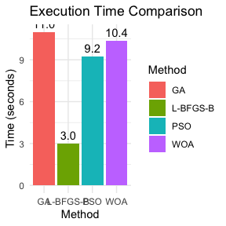

```r
# Plot timing comparison (excluding NA values)
timing_df_filtered <- timing_df[!is.na(timing_df$Time_Seconds),]

if(nrow(timing_df_filtered) > 0) {
  ggplot(timing_df_filtered, aes(x = Method, y = Time_Seconds, fill = Method)) +
    geom_bar(stat = "identity") +
    theme_minimal() +
    labs(title = "Execution Time Comparison",
         y = "Time (seconds)",
         x = "Method") +
    geom_text(aes(label = sprintf("%.1f", Time_Seconds)), vjust = -0.5)
} else {
  cat("No valid timing values to plot")
}
```

### Visualizing Footprint Trajectories

Let’s visualize how the footprints move from their original positions to their corrected positions for each method:

```r
# Function to create trajectory lines between original and corrected positions
create_trajectories <- function(original_sf, corrected_sf, method_name) {
  # Extract centroids
  orig_points <- st_centroid(original_sf)
  corr_points <- st_centroid(corrected_sf)

  # Create a data frame with line start and end coordinates
  n_points <- nrow(orig_points)

  # Take a sample if there are too many points
  max_sample <- 50
  if (n_points > max_sample) {
    sample_indices <- sample(1:n_points, max_sample)
    orig_points <- orig_points[sample_indices,]
    corr_points <- corr_points[sample_indices,]
    n_points <- max_sample
  }

  orig_coords <- st_coordinates(orig_points)
  corr_coords <- st_coordinates(corr_points)

  # Create line segments for each point pair
  lines_list <- list()
  for (i in 1:n_points) {
    pt1 <- c(orig_coords[i, 1], orig_coords[i, 2])
    pt2 <- c(corr_coords[i, 1], corr_coords[i, 2])
    lines_list[[i]] <- st_linestring(rbind(pt1, pt2))
  }

  # Convert to sf object
  lines_sf <- st_sf(
    ID = 1:length(lines_list),
    Method = rep(method_name, length(lines_list)),
    geometry = st_sfc(lines_list, crs = st_crs(original_sf))
  )

  return(lines_sf)
}

# Access the position_adjustment correctly based on package structure
get_adjusted_footprints <- function(result) {
  if (is.null(result)) return(NULL)

  # Check which slot contains the adjusted data
  if (!is.null(result$position_adjustment)) {
    return(result$position_adjustment)
  } else if (!is.null(result$corrected_footprints)) {
    return(result$corrected_footprints)
  } else {
    return(NULL)
  }
}

# Create trajectories if results are available
trajectories_list <- list()
trajectory_count <- 1

# Add GA trajectories
ga_adjusted <- get_adjusted_footprints(ga_result)
if (!is.null(ga_adjusted)) {
  ga_trajectories <- create_trajectories(lidar_footprints_3857, ga_adjusted, "GA")
  trajectories_list[[trajectory_count]] <- ga_trajectories
  trajectory_count <- trajectory_count + 1
}

# Add PSO trajectories
pso_adjusted <- get_adjusted_footprints(pso_result)
if (!is.null(pso_adjusted)) {
  pso_trajectories <- create_trajectories(lidar_footprints_3857, pso_adjusted, "PSO")
  trajectories_list[[trajectory_count]] <- pso_trajectories
  trajectory_count <- trajectory_count + 1
}

# Add WOA trajectories if available
woa_adjusted <- get_adjusted_footprints(woa_result)
if (!is.null(woa_adjusted)) {
  woa_trajectories <- create_trajectories(lidar_footprints_3857, woa_adjusted, "WOA")
  trajectories_list[[trajectory_count]] <- woa_trajectories
  trajectory_count <- trajectory_count + 1
}

# Add L-BFGS-B trajectories if available
lbfgsb_adjusted <- get_adjusted_footprints(lbfgsb_result)
if (!is.null(lbfgsb_adjusted)) {
  lbfgsb_trajectories <- create_trajectories(lidar_footprints_3857, lbfgsb_adjusted, "L-BFGS-B")
  trajectories_list[[trajectory_count]] <- lbfgsb_trajectories
  trajectory_count <- trajectory_count + 1
}

# Print number of available methods for plotting
cat("Number of methods with available trajectory data:", length(trajectories_list), "\n")
```

```
#> Number of methods with available trajectory data: 4
```

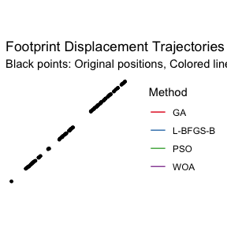

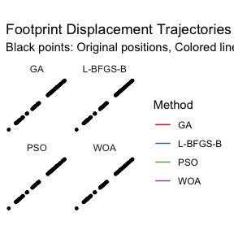

```r
# Check available methods for plotting
if (length(trajectories_list) > 0) {
  all_trajectories <- do.call(rbind, trajectories_list)

  # Create a plot of the trajectories
  plot1 <- ggplot() +
    geom_sf(data = all_trajectories, aes(color = Method), size = 0.5) +
    geom_sf(data = st_centroid(lidar_footprints_3857), size = 1, color = "black") +
    theme_minimal() +
    labs(title = "Footprint Displacement Trajectories",
         subtitle = "Black points: Original positions, Colored lines: Displacement vectors") +
    scale_color_brewer(palette = "Set1") +
    coord_sf(datum = NA)

  print(plot1)

  # Create a faceted plot by method
  if (length(trajectories_list) > 1) {
    plot2 <- ggplot() +
      geom_sf(data = all_trajectories, aes(color = Method), size = 0.5) +
      geom_sf(data = st_centroid(lidar_footprints_3857), size = 1, color = "black") +
      facet_wrap(~ Method) +
      theme_minimal() +
      labs(title = "Footprint Displacement Trajectories by Method",
           subtitle = "Black points: Original positions, Colored lines: Displacement vectors") +
      scale_color_brewer(palette = "Set1") +
      coord_sf(datum = NA)

    print(plot2)
  }
} else {
  cat("No valid trajectory data to plot\n")
}
```

### Displacement Magnitude Distribution

Let’s also visualize the distribution of displacement distances for each method:

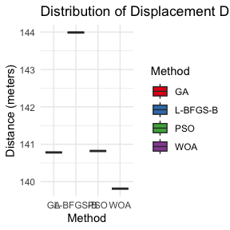

```r
# Function to calculate displacement distances
calc_displacements <- function(original_sf, corrected_sf, method_name) {
  # Extract centroids
  orig_points <- st_centroid(original_sf)
  corr_points <- st_centroid(corrected_sf)

  # Calculate distances
  orig_coords <- st_coordinates(orig_points)
  corr_coords <- st_coordinates(corr_points)

  dx <- corr_coords[, 1] - orig_coords[, 1]
  dy <- corr_coords[, 2] - orig_coords[, 2]
  distance <- sqrt(dx^2 + dy^2)

  # Return as data frame
  data.frame(
    Distance = distance,
    Method = method_name
  )
}

# Create displacement data frames
displacement_list <- list()

if (!is.null(ga_result$corrected_footprints)) {
  ga_displacements <- calc_displacements(
    lidar_footprints_3857,
    ga_result$corrected_footprints,
    "GA"
  )
  displacement_list[[1]] <- ga_displacements
}

if (!is.null(pso_result$corrected_footprints)) {
  pso_displacements <- calc_displacements(
    lidar_footprints_3857,
    pso_result$corrected_footprints,
    "PSO"
  )
  displacement_list[[2]] <- pso_displacements
}

if (!is.null(woa_result) && !is.null(woa_result$corrected_footprints)) {
  woa_displacements <- calc_displacements(
    lidar_footprints_3857,
    woa_result$corrected_footprints,
    "WOA"
  )
  displacement_list[[3]] <- woa_displacements
}

if (!is.null(lbfgsb_result) && !is.null(lbfgsb_result$corrected_footprints)) {
  lbfgsb_displacements <- calc_displacements(
    lidar_footprints_3857,
    lbfgsb_result$corrected_footprints,
    "L-BFGS-B"
  )
  displacement_list[[4]] <- lbfgsb_displacements
}

# Combine all displacements
if (length(displacement_list) > 0) {
  all_displacements <- do.call(rbind, displacement_list)

  # Create a density plot of displacement distances
  ggplot(all_displacements, aes(x = Distance, fill = Method)) +
    geom_density(alpha = 0.5) +
    theme_minimal() +
    labs(title = "Distribution of Displacement Distances",
         x = "Distance (meters)",
         y = "Density") +
    scale_fill_brewer(palette = "Set1")

  # Create a boxplot of displacement distances
  ggplot(all_displacements, aes(x = Method, y = Distance, fill = Method)) +
    geom_boxplot() +
    theme_minimal() +
    labs(title = "Distribution of Displacement Distances",
         x = "Method",
         y = "Distance (meters)") +
    scale_fill_brewer(palette = "Set1")
} else {
  cat("No valid displacement data to plot")
}
```

## Comparison of Optimization Methods

### Performance Guidelines

Based on extensive testing with satellite lidar alignment problems:

1. For small search spaces (<60 meters displacement):
   - Gradient-based methods like L-BFGS-B are typically fastest and most efficient
   - Can be 2-5x faster than metaheuristic methods
2. For complex terrain with multiple optima:
   - GA tends to find better global solutions
   - PSO may converge prematurely in some cases
3. For very large datasets:
   - Consider batch processing techniques for memory efficiency
4. For optimal PSO performance:
   - Use smaller swarm sizes (10-30) for faster convergence
   - Set appropriate tolerance parameters to avoid unnecessary iterations
   - For well-behaved functions, PSO with early stopping can approach gradient-based method speed

## Distance Metrics

The `salpa` package provides various distance metrics for comparing sequences:

1. **Euclidean Distance** (default): Standard distance measure, good for most applications
2. **Dynamic Time Warping (DTW)**: Accounts for temporal shifts in sequences
3. **Manhattan Distance**: Less sensitive to outliers than Euclidean
4. **Correlation Distance**: Based on correlation between sequences, scale-invariant
5. **Area Distance**: Calculates the area between sequences, good for curve matching
6. **Hausdorff Distance**: Measures maximum distance between closest points in sets

Example:

```r
# Using different distance metrics
dtw_result <- positional_correction(
  lidar_footprints = lidar_footprints_3857,
  input_rast = dem_rast,
  minimizing_method = "dtw",  # Can be "euclidean", "dtw", "manhattan", "correlation", "area", or "hausdorff"
  target_variable = "mean",
  lidar_value = "gedi_dem",
  optimization_method = "ga"
)
```

## Conclusion

The `salpa` package provides a comprehensive toolkit for improving the spatial accuracy of satellite lidar data. By offering multiple optimization algorithms and distance metrics, it can handle various types of terrain and lidar datasets.

Each optimization method has its strengths:

- **Genetic Algorithm (GA)**: Provides robust performance for complex terrain and can avoid local minima. Best for general-purpose use when computational resources are not constrained.
- **Particle Swarm Optimization (PSO)**: Offers a good balance between speed and accuracy. Particularly effective when dealing with smooth fitness landscapes.
- **Whale Optimization Algorithm (WOA)**: Excels at balancing exploration and exploitation, making it suitable for diverse terrain types and when local optima are an issue.
- **L-BFGS-B**: Most computationally efficient for well-behaved functions and large datasets. Ideal when dealing with smooth DEM surfaces and when computation time is a constraint.

When selecting a method, consider the nature of your terrain (complex vs. smooth), computational constraints, and the specific characteristics of your lidar dataset.